# Genie Game Results — Final

# Exclusions

```r
full_pdf = load_data('participants') %>%
    filter(completed) %>%
    select(-c(consideration_time, reflection_time, n_considered, n_unconsidered, version, bonus, completed)) %>%
    mutate(
        obligatory_check = factor(if_else(comp_radio, 'incorrect', 'correct', 'empty'),
                                  levels=c('empty', 'incorrect', 'correct')),
    )

full_df = load_data('evaluation') %>%
    rename(scenario = prompt_id) %>%
    mutate(scenario = tolower(scenario))

full_consideration = load_data('consideration') %>%
    rename(scenario = prompt_id) %>%
    mutate(scenario = tolower(scenario))

full_slider = load_data('slider_check')

slider_check = full_slider %>%
    mutate(prompt = word(prompt)) %>%
    pivot_wider(names_from=prompt, values_from=response) %>%
    mutate(
        p1 = Breaking < Stubbing,
        p2 = Stubbing < Finding,
        p3 = Finding < Winning,
        pass = p1 & p2 & p3
    )

# slider_check %>% summarise(across(-wid, mean))

# table(full_pdf$obligatory_check)
pdf = full_pdf %>%
    filter(obligatory_check == "correct") %>%
    left_join(slider_check) %>%
    filter(pass) %>%
    mutate(
        control = factor(control, levels=c("low", "high"))
    )

pdf2 = select(pdf, wid, control)

consideration = full_consideration %>%
    right_join(pdf2)  %>%
    filter(scenario != "practice") %>%
    filter(outcome %nin% c("NONE", "UNK")) %>%
    select(-raw_outcome) %>%
    group_by(wid, scenario) %>%
    mutate(order = row_number())

df = full_df %>%
    right_join(pdf2) %>%
    filter(scenario != "practice") %>%
    left_join(transmute(consideration, wid, scenario, outcome, order, considered=T)) %>%
    replace_na(list(considered=F)) %>%
    group_by(wid) %>%
    mutate(
        evaluation_z = zscore(evaluation),
        abs_eval = abs(evaluation),
        abs_eval_z = zscore(abs_eval),
    ) %>%
    ungroup()

acc = read_csv('../data/acc-v2.0/accessibility.csv', col_types = cols())

acc %>%
    filter(cat_id != "EUROCITIES") %>%
    filter(outcome != "UNK") %>%
    count(outcome) %>%
    mutate(accessibility = n / length(unique(acc$wid))) %>%
    select(-n) %>%
    right_join(df) -> df

# stopifnot(df %>% group_by(wid, scenario) %>% filter(sum(considered)!=1) %>% nrow == 0)
stopifnot(df %>% filter(is.na(accessibility)) %>% nrow == 0)

df %>%
    arrange(wid, scenario, order) %>%
    write_csv("../data/processed.csv")
```

# Proportion of good/bad/neutral

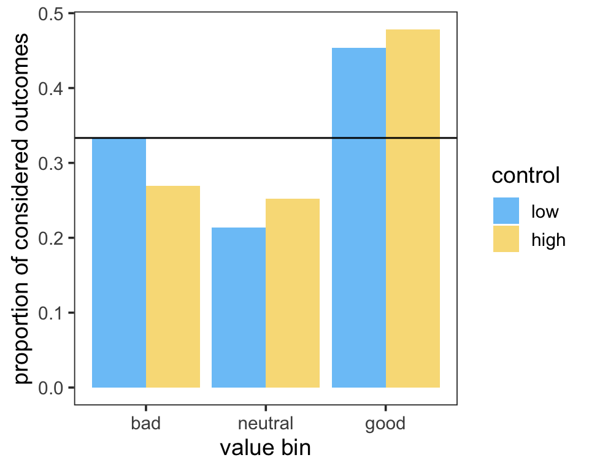

```r
ebins = df %>%
    group_by(evaluation) %>%
    summarise(acc=sum(accessibility)) %>%
    mutate(prop=acc/sum(acc)) %>%
    mutate(ebin=cut(cumsum(prop), c(0, 1/3, 2/3, 1.01), labels=c("bad", "neutral", "good"))) %>%
    select(evaluation, ebin)

df %>%
    left_join(ebins) %>%
    filter(considered)  %>%
    ggplot(aes(ebin, y=..prop.., group=control,fill=control)) +
    geom_bar(position="dodge", alpha=0.7) +
    geom_hline(yintercept=1/3, linetype="solid") +
    control_colors +
    labs(x="value bin", y="proportion of considered outcomes")
```

```r
baselines = df %>%
    group_by(evaluation) %>%
    summarise(acc=sum(accessibility))  %>%
    mutate(prop=acc/sum(acc))

X = baselines %>%
    mutate(ebin=cut(cumsum(prop), c(0, 1/3, 2/3, 1.01), labels=c("bad", "neutral", "good"))) %>%
    select(evaluation, ebin) %>%
    right_join(df) %>%
    filter(considered) %>%
    count(control, ebin) %>%
    pivot_wider(names_from=ebin, values_from=n) %>%
    mutate(total=bad+neutral+good)
```

## Tests

```r
low =  X %>% filter(control=="low")
high = X %>% filter(control=="high")

cat(
    "\n\nlow-control good > chance:",
    pval(prop.test(low$good, low$total, 1/3, 'greater')$p.value),
    "\n\nlow-control bad > chance:",
    pval(prop.test(low$bad, low$total, 1/3, 'greater')$p.value),
    "\n\nlow-control neutral < chance:",
    pval(prop.test(low$neutral, low$total, 1/3, 'less')$p.value),
    "\n\nhigh-control good > chance:",
    pval(prop.test(high$good, high$total, 1/3, 'greater')$p.value),
    "\n\nhigh-control bad > chance:",
    pval(prop.test(high$bad, high$total, 1/3, 'less')$p.value),
    "\n\nhigh-control neutral < chance:",
    pval(prop.test(high$neutral, high$total, 1/3, 'less')$p.value),
    "\n\nlow bad > high bad:",
    pval(prop.test(X$bad, X$total, alternative='greater')$p.value),
    "\n\nhigh good > low good:",
    pval(prop.test(X$good, X$total, alternative='less')$p.value)
)
```

[output not shown]

low-control good > chance: p < .001

low-control bad > chance: p = .505

low-control neutral < chance: p < .001

high-control good > chance: p < .001

high-control neutral < chance: p < .001

low bad > high bad: p = .011

high good > low good: p = .211

# Regression “check” plot

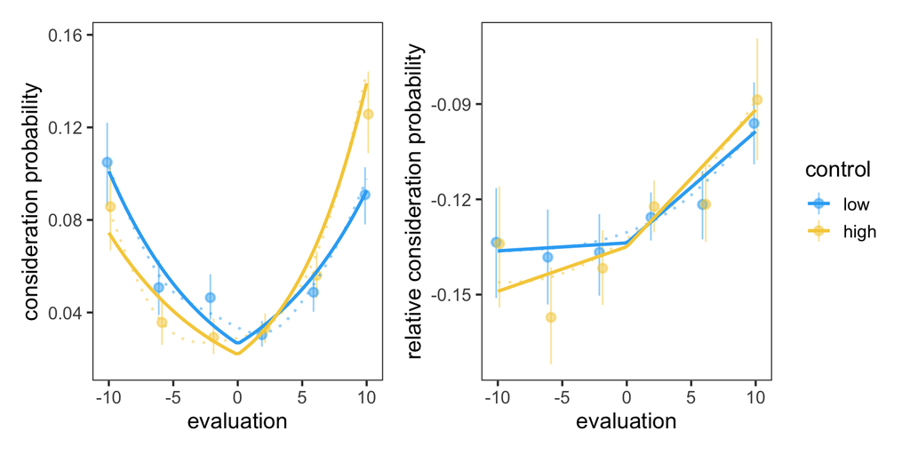

```r
# BASELINE = mean(df$evaluation)

relu = function(x) {
    if_else(x < 0, 0, x)
}

p1 = df %>%
    ggplot(aes(evaluation, as.numeric(considered), color=control)) +
    stat_summary_bin(fun.data=mean_cl_boot, bins=5, alpha=0.5,
                     position=position_dodge(width=.5)) +
    stat_smooth(geom="line", size=0.8, linetype = "dotted", alpha=0.5) +
    # geom_smooth(se=F, method=lm, formula=y ~ x + abs(x), alpha=0.1) +
    geom_smooth(se=F, method=glm,
        formula=y ~ relu(x) + abs(x),
        method.args = list(family = "binomial"),
        alpha=0.1) +
    ylab("consideration probability") +
    control_colors

p2 = df %>%
    ggplot(aes(evaluation, considered - accessibility, color=control)) +
    stat_summary_bin(fun.data=mean_cl_boot, bins=5, alpha=0.5,
                     position=position_dodge(width=.5)) +
    stat_smooth(geom="line", size=0.8, linetype = "dotted", alpha=0.5) +
    geom_smooth(se=F, method=lm, formula=y ~ abs(x) + relu(x), alpha=0.1) +
    # geom_smooth(se=F, method=lm, formula=y ~ exp(0.2*x) + abs(x), alpha=0.1) +
    ylab("relative consideration probability") +
    control_colors

p1 + p2 + plot_layout(guides = "collect")
```

# Value distributions

Gray is the accessibility data. Blue and yellow are outcomes considered by each group.

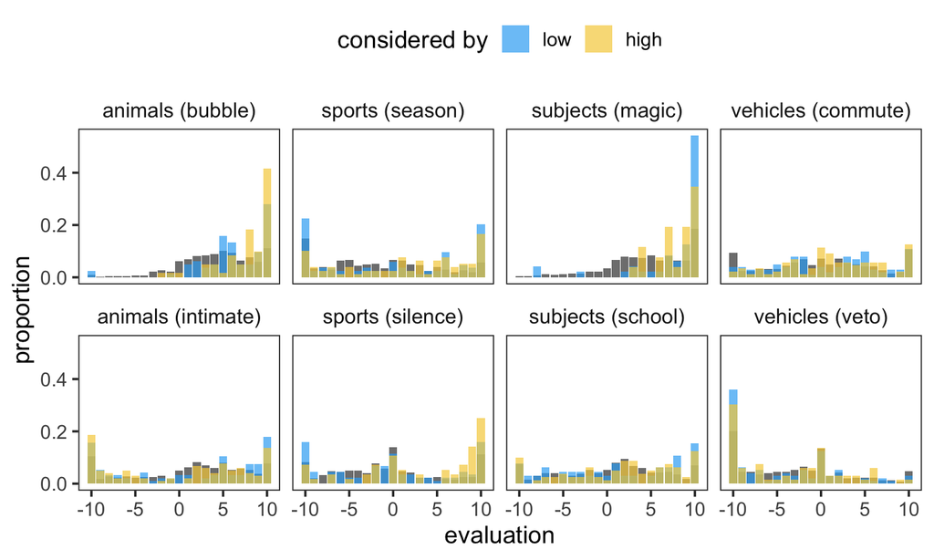

```r
wrap_scenario = list(
    facet_wrap(~scenario, dir="v", ncol=4),
    theme(strip.text.x = element_text(size=12), legend.position="top")
)

baselines = df %>%
    group_by(scenario, evaluation) %>%
    summarise(acc=sum(accessibility))  %>%
    group_by(scenario) %>%
    mutate(prop=acc/sum(acc))

df %>%
    filter(considered) %>%
    count(control, scenario, evaluation) %>%
    group_by(control, scenario) %>%
    mutate(prop=n/sum(n)) %>%
    ggplot(aes(evaluation, prop)) +
        geom_bar(data=baselines, stat="identity", alpha=1, fill="gray50", position="identity") +
        geom_bar(aes(fill=control), stat="identity", alpha=0.7, position="identity") +
        control_colors + wrap_scenario +
        labs(fill="considered by", y="proportion")
```

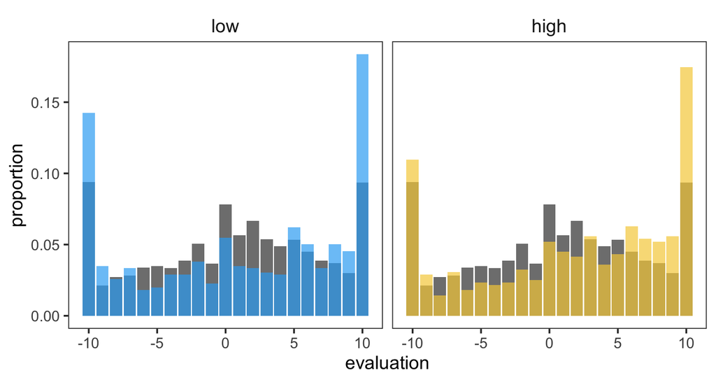

```r
baselines = df %>%
    group_by(evaluation) %>%
    summarise(acc=sum(accessibility))  %>%
    mutate(prop=acc/sum(acc))

df %>%
    filter(considered) %>%
    count(control, evaluation) %>%
    group_by(control) %>%
    mutate(prop=n/sum(n)) %>%
    ggplot(aes(evaluation, prop)) +
        geom_bar(data=baselines, stat="identity", alpha=1, fill="gray50", position="identity") +
        geom_bar(aes(fill=control), stat="identity", alpha=0.7, position="identity") +
        control_colors + facet_wrap(~control) +
        labs(fill="considered by", y="proportion") +
        theme(legend.position="none")
```

## Relative proportions

New plot: this is like the above but subtracting out the accessibility value. It shows how much more frequent each value among considered outcomes than we would expect from accessibility alone.

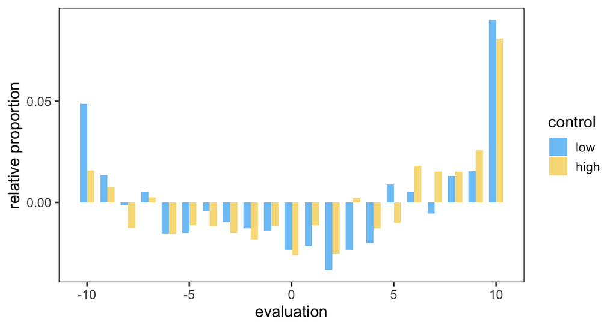

```r
baselines = df %>%
    group_by(evaluation) %>%
    summarise(acc=sum(accessibility))  %>%
    mutate(prop=acc/sum(acc))

df %>%
    filter(considered) %>%
    count(control, evaluation) %>%
    group_by(control) %>%
    mutate(prop=n/sum(n)) %>%
    left_join(transmute(baselines, evaluation, baseline=prop)) %>%
    ggplot(aes(evaluation, prop-baseline)) +
        geom_bar(aes(fill=control), stat="identity", alpha=0.7, width=.7, position="dodge") +
        control_colors +
        labs(y="relative proportion")
```

# Modeling

## Model comparison

- loo is an estimate of predictive likelihood; it will be close to AIC / -2.
- d_loo is the difference in loo from the best model
- dse is the standard error of that difference
- weight “can be loosely interpreted as the probability of each model (among the compared model) given the data”

```r
read_csv("../model/results/comparison.csv") %>%
    select(name, loo, d_loo, dse, weight) %>%
    mutate(across(-name, signif, 4)) %>%
    kable
```

| name | loo | d_loo | dse | weight |
| --- | --- | --- | --- | --- |
| switching_softmax_uws | -2794 | 0.00 | 0.000 | 0.75400 |
| softmax_uws | -2798 | 4.20 | 3.677 | 0.09034 |
| switch_softmax | -2822 | 28.29 | 7.745 | 0.06948 |
| switch_uws | -2841 | 46.88 | 10.800 | 0.08621 |

I’m not exactly sure how to interpret the dse, but the most obvious interpretation to me is that it could have easily come out the other direction.

## Difference in β

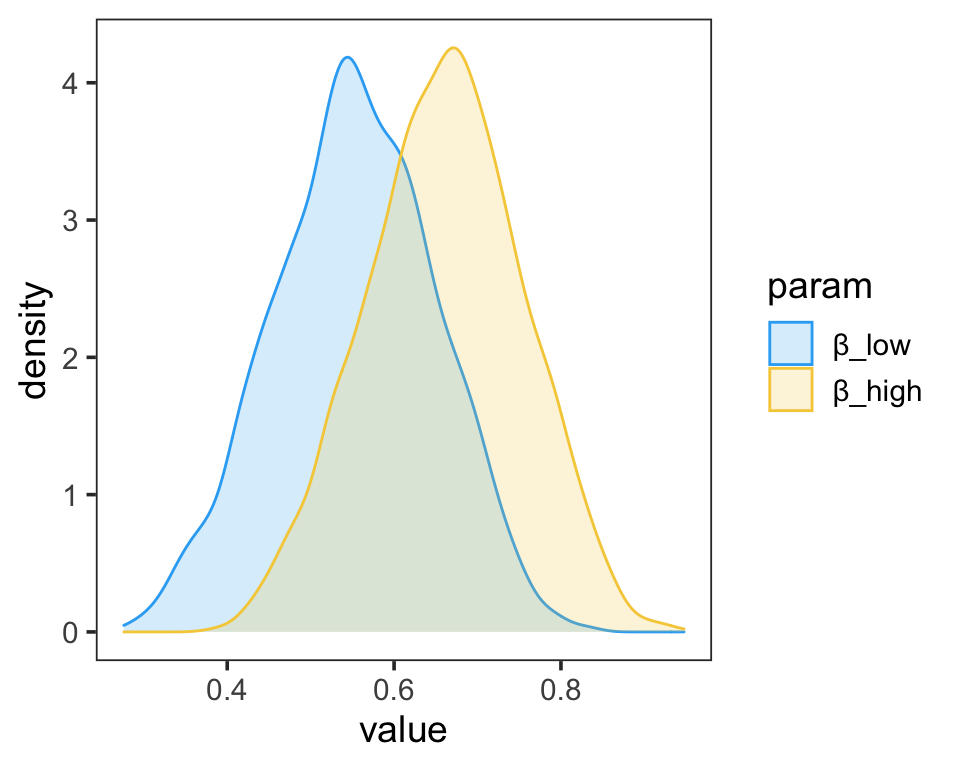

```r
chain = read_csv('../model/results/chain.csv')

chain %>%
    select(β_low, β_high) %>%
    pivot_longer(c(β_low, β_high), names_to="param", values_to="value", names_prefix="") %>%
    mutate(param = factor(param, levels=c("β_low", "β_high"))) %>%
    ggplot(aes(value, fill=param, color=param)) +
    geom_density(alpha=0.2) + control_colors
```

```r
p_higher = mean(chain$β_high > chain$β_low)
```

It looks like they overlap a lot, but this is (likely) because they both correlate with the $C_{\text{exp}}$ parameter. If we compare them, $\beta_{\text{high}}$ is higher 99.9% of the time.

## Posterior predictive checks

Here we are recreating plots using simulations from the joint model.

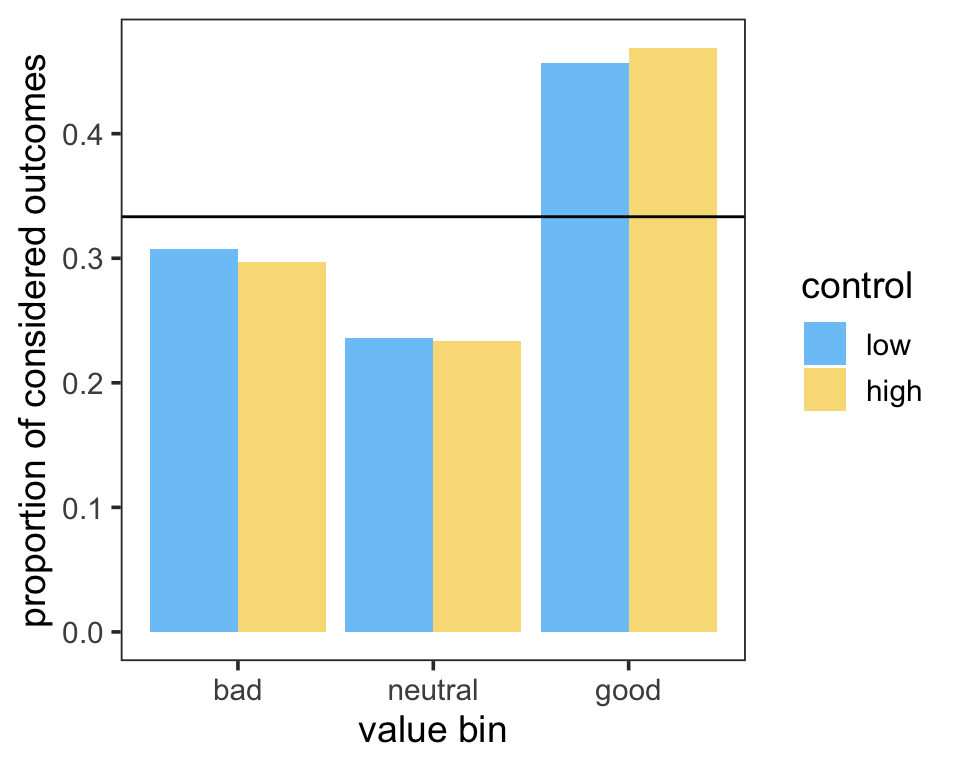

```r
ppc = read_csv("../model/results/ppc.csv") %>%
    pivot_longer(c(low, high), names_to="control", values_to="n", names_prefix="") %>%
    mutate(control = factor(control, levels=c("low", "high")))

ppc %>%
    left_join(ebins) %>%
    group_by(control,ebin) %>%
    summarise(n=sum(n)) %>%
    group_by(control) %>%
    mutate(prop = n / sum(n)) %>%
    ggplot(aes(ebin, y=prop, group=control,fill=control)) +
    geom_bar(position="dodge", stat="identity", alpha=0.7) +
    geom_hline(yintercept=1/3, linetype="solid") +
    control_colors +
    labs(x="value bin", y="proportion of considered outcomes")
```

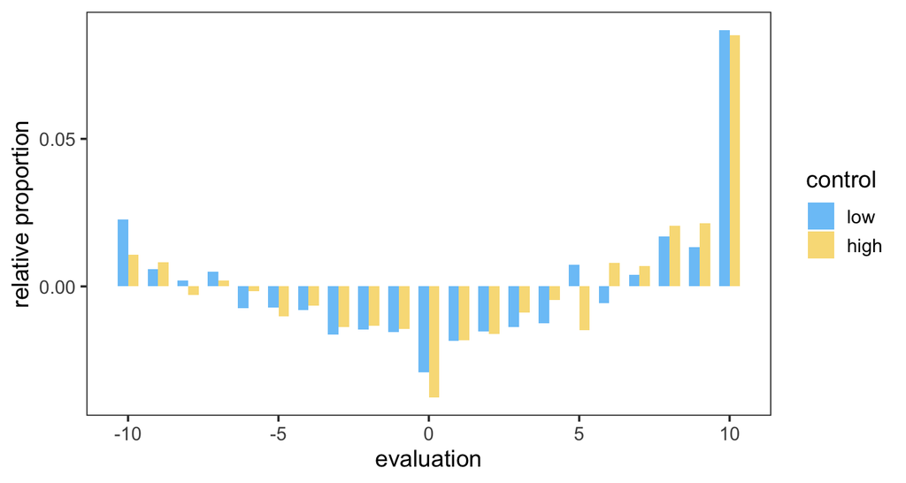

```r
ppc %>%
    group_by(control) %>%
    mutate(prop=n/sum(n)) %>%
    left_join(transmute(baselines, evaluation, baseline=prop)) %>%
    ggplot(aes(evaluation, prop-baseline)) +
        geom_bar(aes(fill=control), stat="identity", alpha=0.7, width=.7, position="dodge") +
        control_colors +
        labs(y="relative proportion")
```